# modelosMixtos

## Modelo Mixtos Gaussianos

Usaremos el paquete "mclust" de R; hay otros paquetes que hacen lo mismo. También existen opciones en Python y Julia.

Recordemos que suponemos que nuestros datos se generar a partir de una mixtura de normales según el siguiente modelo:

$$Z \sim Cat(\pi_1, \dots, p_K) \ \ \ \mbox{y} \ \ \ X|Z=j \sim N(\mu_j, \Sigma_j).$$

### Ejercicio: velocidad de la galaxias

Vamos a utilizar el dataset *galaxies*, en la libreria MASS de R, que contiene las velocidades medidas en km/seg para 82 estrellas de regiones cónicas bien separadas de la región [Corona Borealis](https://es.wikipedia.org/wiki/Corona_Borealis). En este tipo de estudios la multimodalidad se toma como evidencia para la existencia de vacíos y supercúmulos en el universo lejano.

```r
library(mclust)
library(MASS)

data(galaxies)
galaxies
```

```
Package 'mclust' version 5.4.7
```

1. 9172

2. 9350

3. 9483

4. 9558

5. 9775

6. 10227

7. 10406

8. 16084

9. 16170

10. 18419

11. 18552

12. 18600

13. 18927

14. 19052

15. 19070

16. 19330

17. 19343

18. 19349

19. 19440

20. 19473

21. 19529

22. 19541

23. 19547

24. 19663

25. 19846

26. 19856

27. 19863

28. 19914

29. 19918

30. 19973

31. 19989

32. 20166

33. 20175

34. 20179

35. 20196

36. 20215

37. 20221

38. 20415

39. 20629

40. 20795

41. 20821

42. 20846

43. 20875

44. 20986

45. 21137

46. 21492

47. 21701

48. 21814

49. 21921

50. 21960

51. 22185

52. 22209

53. 22242

54. 22249

55. 22314

56. 22374

57. 22495

58. 22746

59. 22747

60. 22888

61. 22914

62. 23206

63. 23241

64. 23263

65. 23484

66. 23538

67. 23542

68. 23666

69. 23706

70. 23711

71. 24129

72. 24285

73. 24289

74. 24366

75. 24717

76. 24990

77. 25633

78. 26690

79. 26995

80. 32065

81. 32789

82. 34279

```r
## Estimación de parámetros mediante EM

mixmod = densityMclust(galaxies) # Modelo no estamos aclarando cuantos clusters, lo estima de forma autómatica, ya veremos cómo.
summary(mixmod, parameters=TRUE) # Reporte del modelo
mixmod$BIC
```

```
-------------------------------------------------------
Density estimation via Gaussian finite mixture modeling
-------------------------------------------------------

Mclust V (univariate, unequal variance) model with 4 components:

 log-likelihood  n df       BIC       ICL
       -765.694 82 11 -1579.862 -1598.907

Mixing probabilities:
         1          2          3          4
0.08440635 0.38660329 0.37116156 0.15782880

Means:
        1         2         3         4
 9707.492 19804.259 22879.486 24459.536

Variances:
         1          2          3          4
  177296.7   436160.9  1261611.3 34437115.3
```

```
Bayesian Information Criterion (BIC):
          E         V
1 -1622.361 -1622.361
2 -1631.243 -1595.403
3 -1584.016 -1592.299
4 -1592.828 -1579.862
5 -1592.299 -1593.277
6 -1601.228 -1604.069
7 -1588.610 -1611.538
8 -1597.427 -1625.804
9 -1600.709 -1633.494

Top 3 models based on the BIC criterion:
      V,4       E,3       E,7
-1579.862 -1584.016 -1588.610
```

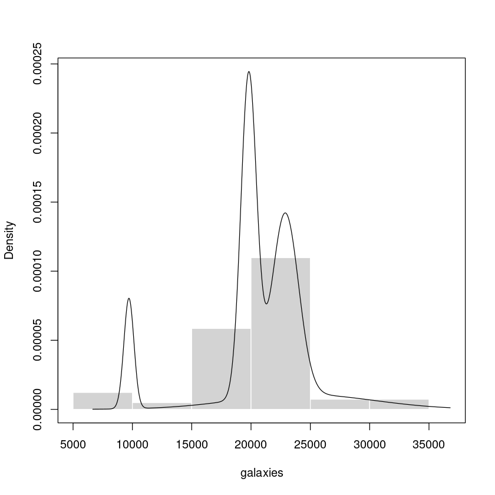

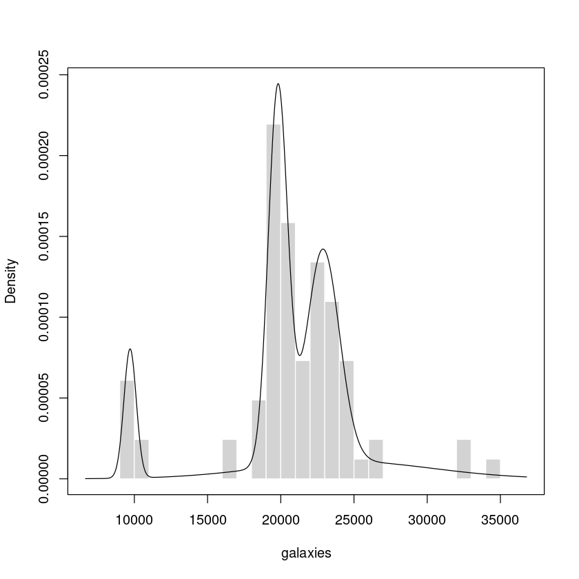

```r
plot(mixmod, what="density", data=galaxies)

# Observemos lo que sucede si tomamos 20 breaks para el histograma

plot(mixmod, what="density", data=galaxies, breaks=20)
```

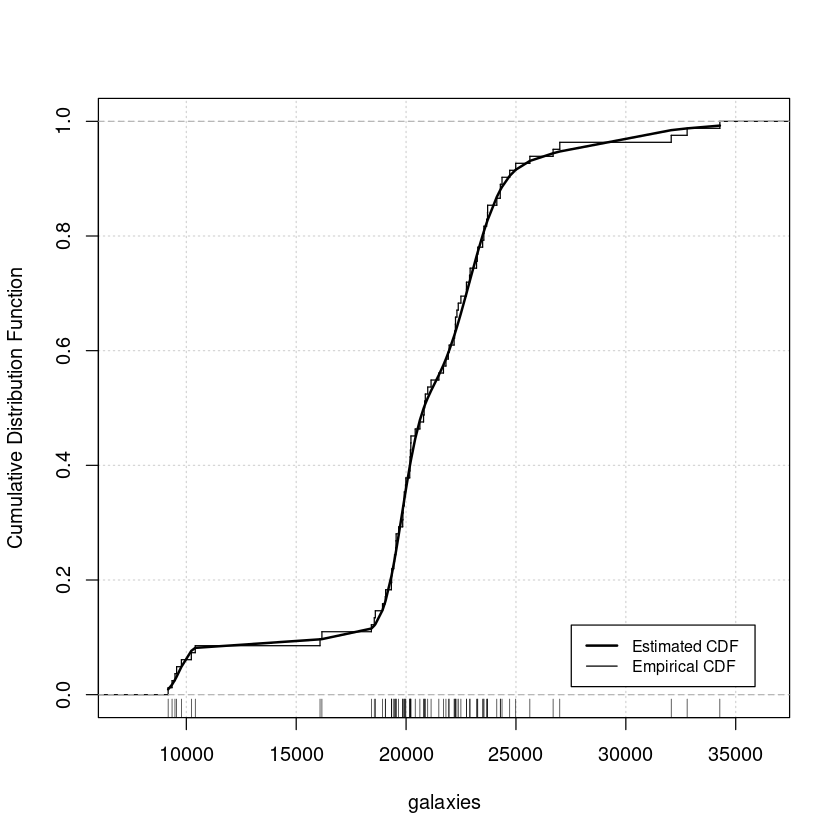

```r
## Gráfico de diagnóstico: comparación contra la empírica

plot(mixmod, what = "diagnostic", type = "cdf")
```

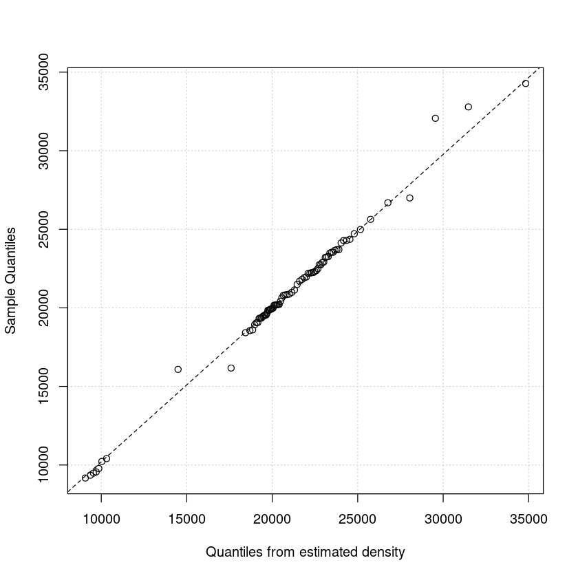

```r
## Gráfico de diagnóstico: qqplot

plot(mixmod, what = "diagnostic", type = "qq")
```

## BIC: Bayesian Information Criteria

$$BIC = 2Loglik_{M} \left(x_1, \dots, x_n, \hat{\theta} \right) − M_m log(n),$$

- $n$ es la cantidad de observaciones
- $M$ es el modelo mixto que estoy considerando.
- $M_m$ es la cantidad de parámetros libres que se estiman.
- $\hat{\theta}$ es el estimador de los parámetros del modelo de máxima verosimilitud.

En efecto el BIC es un criterio de selección de modelos. Compara la verosimilitud obtenida con la cantidad de parámetros que estoy considerando. Si tomo demasiados parámetros puedo caer en el sobreajuste y si no son suficientes puedo tener un mal modelo. Se toma como "mejor" modelo el que maximize el BIC.

**ACLARACIÓN:** otras implementaciones pueden tomar el BIC de otra forma y el mejor modelo puede ser el que minimiza el BIC. Si buscan en Wikipedia van a ver que la definición es igual, pero multiplicada por -1.

```r
mixmod$BIC
```

```
Bayesian Information Criterion (BIC):
          E         V
1 -1622.361 -1622.361
2 -1631.243 -1595.403
3 -1584.016 -1592.299
4 -1592.828 -1579.862
5 -1592.299 -1593.277
6 -1601.228 -1604.069
7 -1588.610 -1611.538
8 -1597.427 -1625.804
9 -1600.709 -1633.494

Top 3 models based on the BIC criterion:
      V,4       E,3       E,7
-1579.862 -1584.016 -1588.610
```

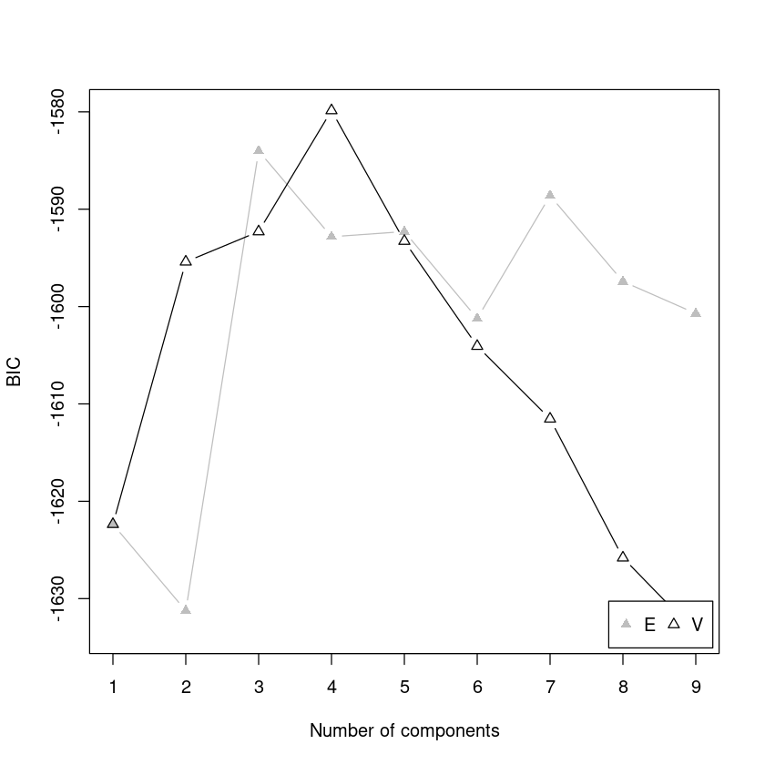

```r
plot(mixmod, what="BIC")
```

## Ejercicio: diabetes

Para este ejercicio vamos a considerar el dataset *diabetes* que se encuentra en la librería mclust. Este conjunto de datos contiene tres mediciones hechas en 145 pacientes adultos no obesos clasificadas en tres grupos.

|  | class | glucose | insulin | sspg |
| --- | --- | --- | --- | --- |
| 1 | Normal | 80 | 356 | 124 |
| 2 | Normal | 97 | 289 | 117 |
| 3 | Normal | 105 | 319 | 143 |
| 4 | Normal | 90 | 356 | 199 |
| 5 | Normal | 90 | 323 | 240 |

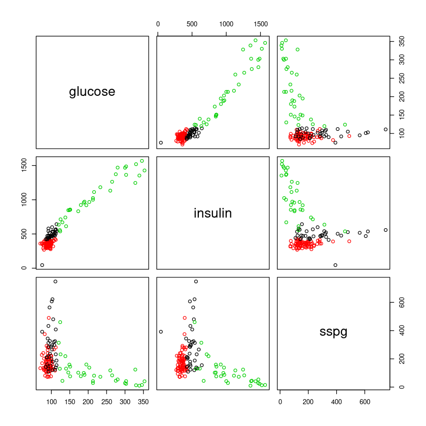

```r
data(diabetes)
mediciones = diabetes[,-1]

plot(mediciones, col=diabetes$class)
```

```
Best BIC values:
             VVV,3       VVV,4       EVE,6
BIC      -4751.316 -4784.32213 -4785.24591
BIC diff     0.000   -33.00573   -33.92951
```

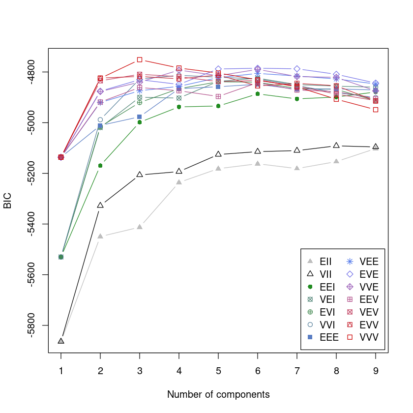

```r
## Usemos mclust para ajustar un modelo mixtos sobre los datos sin las etiquetas

BIC = mclustBIC(mediciones)
plot(BIC)
summary(BIC)
```

## Modelos que considera mclust: tipos de covarianzas

Se toman tres parámetros para parametrizar las covarianzas

[figure not shown]

## Códigos de referencias

| Modelo | $\Sigma_k$ | Distribución | Volumen | Forma | Orientación |
| --- | --- | --- | --- | --- | --- |
| EII | $\lambda I$ | Esférica | Igual | Igual | — |
| VII | $\lambda_k I$ | Esférica | Variable | Igual | — |
| EEI | $\lambda A$ | Diagonal | Igual | Igual | Ejes |
| VEI | $\lambda_k A$ | Diagonal | Variable | Igual | Ejes |
| EVI | $\lambda A_k$ | Diagonal | Igual | Variable | Ejes |
| VVI | $\lambda_k A_k$ | Diagonal | Variable | Variable | Ejes |
| EEE | $\lambda DAD'$ | Ellipsoidal | Igual | Igual | Igual |
| EVE | $\lambda D A_k D'$ | Ellipsoidal | Igual | Variable | Igual |
| VEE | $ \lambda_k DAD'$ | Ellipsoidal | Variable | Igual | Igual |
| VVE | $\lambda_k D A_k D'$ | Ellipsoidal | Variable | Variable | Igual |
| EEV | $\lambda D_k A D_{k}'$ | Ellipsoidal | Igual | Igual | Variable |
| VEV | $\lambda_k D_k A D_{k}'$ | Ellipsoidal | Variable | Igual | Variable |
| EVV | $\lambda D_k A_k D_{k}'$ | Ellipsoidal | Igual | Variable | Variable |
| VVV | $\lambda_k D_k A_k D_{k}'$ | Ellipsoidal | Variable | Variable | Variable |

```r
## Clusterizamos

mixmod2 = Mclust(mediciones, x = BIC)
summary(mixmod2, parameters = TRUE)
```

```
----------------------------------------------------
Gaussian finite mixture model fitted by EM algorithm
----------------------------------------------------

Mclust VVV (ellipsoidal, varying volume, shape, and orientation) model with 3
components:

 log-likelihood   n df       BIC       ICL
      -2303.496 145 29 -4751.316 -4770.169

Clustering table:
 1  2  3
81 36 28

Mixing probabilities:
        1         2         3
0.5368974 0.2650129 0.1980897

Means:
             [,1]     [,2]       [,3]
glucose  90.96239 104.5335  229.42136
insulin 357.79083 494.8259 1098.25990
sspg    163.74858 309.5583   81.60001

Variances:
[,,1]
         glucose    insulin       sspg
glucose 57.18044   75.83206   14.73199
insulin 75.83206 2101.76553  322.82294
sspg    14.73199  322.82294 2416.99074
[,,2]
          glucose   insulin       sspg
glucose  185.0290  1282.340  -509.7313
insulin 1282.3398 14039.283 -2559.0251
sspg    -509.7313 -2559.025 23835.7278
[,,3]
          glucose   insulin       sspg
glucose  5529.250  20389.09  -2486.208
insulin 20389.088  83132.48 -10393.004
sspg    -2486.208 -10393.00   2217.533
```

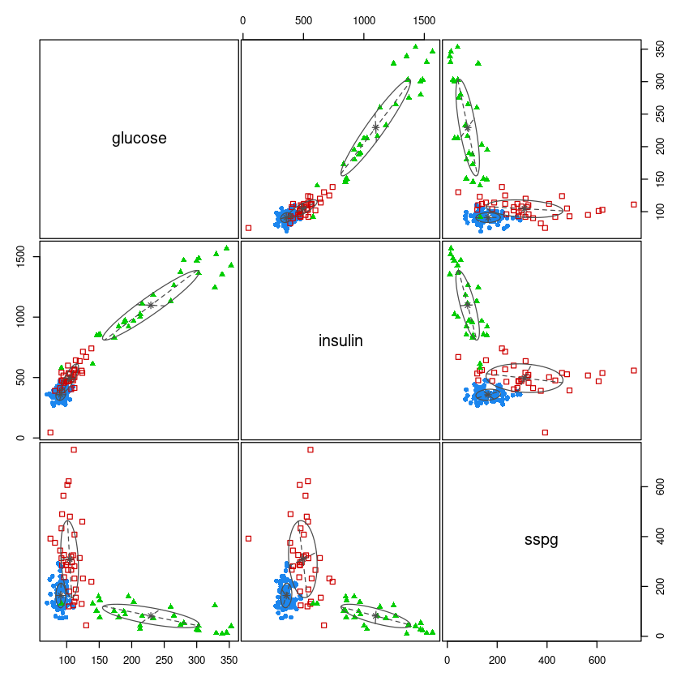

```r
## Ploteamos los clusters

plot(mixmod2, what = "classification")
```

**1:** 0.00925319912410294

0.990746800875897

**1**

1

**2**

1

**3**

1

**4**

1

**5**

1

**6**

1

**7**

1

**8**

1

**9**

1

**10**

1

**11**

1

**12**

1

**13**

1

**14**

1

**15**

1

**16**

1

**17**

1

**18**

1

**19**

1

**20**

1

**21**

1

**22**

1

**23**

1

**24**

1

**25**

1

**26**

1

**27**

1

**28**

1

**29**

1

**30**

1

**31**

1

**32**

1

**33**

1

**34**

1

**35**

1

**36**

1

**37**

1

**38**

1

**39**

1

**40**

1

**41**

1

**42**

1

**43**

1

**44**

1

**45**

1

**46**

1

**47**

1

**48**

1

**49**

1

**50**

1

**51**

1

**52**

1

**53**

1

**54**

1

**55**

1

**56**

1

**57**

1

**58**

1

**59**

1

**60**

1

**61**

1

**62**

1

**63**

1

**64**

1

**65**

1

**66**

1

**67**

1

**68**

1

**69**

2

**70**

1

**71**

2

**72**

1

**73**

1

**74**

1

**75**

2

**76**

2

**77**

1

**78**

1

**79**

1

**80**

1

**81**

1

**82**

2

**83**

1

**84**

1

**85**

2

**86**

2

**87**

2

**88**

2

**89**

2

**90**

2

**91**

2

**92**

2

**93**

2

**94**

2

**95**

2

**96**

2

**97**

2

**98**

2

**99**

2

**100**

2

**101**

2

**102**

2

**103**

2

**104**

2

**105**

1

**106**

2

**107**

3

**108**

2

**109**

2

**110**

1

**111**

2

**112**

2

**113**

3

**114**

3

**115**

2

**116**

3

**117**

3

**118**

3

**119**

3

**120**

3

**121**

3

**122**

3

**123**

3

**124**

3

**125**

3

**126**

3

**127**

3

**128**

3

**129**

3

**130**

3

**131**

2

**132**

3

**133**

3

**134**

2

**135**

2

**136**

2

**137**

2

**138**

3

**139**

3

**140**

3

**141**

3

**142**

3

**143**

3

**144**

3

**145**

3

1. 0.990746800875897

2. 0.0089460185143457

3. 0.000307180609757357

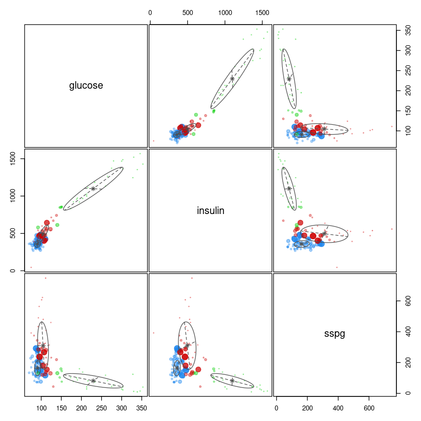

```r
## Ploteamos la incertidubre de la clasificación

plot(mixmod2, what = "uncertainty")
mixmod2$uncertainty[1]
mixmod2$z[1]
mixmod2$classification
mixmod2$z[1,]
```

```r
## Comparamos con lo que tenemos

round(table(real=diabetes$class, clusters=mixmod2$classification)/nrow(diabetes),3)

print("-----------------")

print("Proporción de observaciones en cada clase")
round(table(diabetes$class)/nrow(diabetes),3)

print("-----------------")

print("Proporción de observaciones en cada cluster")
round(table(mixmod2$classification)/nrow(diabetes),3)

print("-----------------")

print("Las famosas pi de las diaps")
round(mixmod2$parameters$pro,3)
```

```
          clusters
real           1     2     3
  Chemical 0.062 0.179 0.007
  Normal   0.497 0.028 0.000
  Overt    0.000 0.041 0.186
```

```
[1] "-----------------"
[1] "Proporción de observaciones en cada clase"
```

```
Chemical   Normal    Overt
   0.248    0.524    0.228
```

```
[1] "-----------------"
[1] "Proporción de observaciones en cada cluster"
```

```
    1     2     3
0.559 0.248 0.193
```

```
[1] "-----------------"
[1] "Las famosas pi de las diaps"
```

1. 0.537

2. 0.265

3. 0.198

## Ejercicio: geyser

Considere el conjunto de datos *geyser* de la libreria MASS. Haga un análisis del dataset.

1- Ajustar un modelo mixto con dos normales multivaridas: *mod1*.

2- Utilize el criterio BIC para seleccionar el mejor modelo: *mod2*.

3- Compare *mod1* con *mod2*.

4- ¿Hay algunos puntos para los cuales no este clara la clasificación?¿Qué puede decir sobre ellos?

5- Explore el paquete mclust o el que quiera utilizar y uselo en el dataset geyser.

## Ejercicio: hacking mixture models

1- Genere un conjunto de datos univariados con una distribución que no sea normal y observe los resultados. (Sugerencia: utilizar una distribución asimétrica)

2- ¿Qué tan sensible es la estimación de parámetros del modelo mixto a la presencia de valores atípicos?

3- ¿Qué sucede cuando la dimensión de los datos es mucho mayor a la cantidad de observaciones?